# Tables

## Data Introduction

For this lab we will be using the `Titanic` dataset built into R, providing information on the fate of the passengers on the fatal maiden voyage of the ocean liner ‘Titanic’ summarized according to economic status (class), sex, age, and survival. See `?Titanic` for more details.

As the `Titanic` dataset in R is, by default, stored as a 4 dimensional array, we will start by transforming it into a data.frame.

```r
library(ggplot2)
library(dplyr)

theme_set(theme_bw())


## Data for lab
titanic <- as.data.frame(Titanic)
titanic <- titanic[rep(1:nrow(titanic), times = titanic$Freq), ]
titanic$Freq <- NULL

## head() shows us the first 6 rows of a data.frame
head(titanic)
```

```
##     Class  Sex   Age Survived
## 3     3rd Male Child       No
## 3.1   3rd Male Child       No
## 3.2   3rd Male Child       No
## 3.3   3rd Male Child       No
## 3.4   3rd Male Child       No
## 3.5   3rd Male Child       No
```

Our goal in this lab is to familiarize ourselves with the use of tables in R. To this end, there are two primary functions we will be concerning ourselves with:

- The `table()` function which returns a count of categorical data
- The `proportion()` function which takes a table as an argument and returns a (optionally conditional) table of proportions

In addition to these, we will introduce four helper functions to assist us:

- The “pipe” operator, `%>%` (Ctrl+Shift+M), which takes the results of the left hand side of the pipe and passes them to the right hand side. This is helpful for “chaining together” a sequence of operations. We will use this extensively later in the semester
- The `sort()` function will sort either a table or numeric vector in increasing or decreasing order
- The `addmargins()` function will sum the margins of a table
- We can use `facet_grid` to facet two nested categorical variables in `ggplot2`

You can learn more about these functions, and see some additional examples, by using the help documentation (i.e., `?table()`).

## Using Tables

Tables are ubiquitous in R.

### One-way tables

The first function we will introduce is the `table()` function; in its most basic form, `table()` takes as its argument a single vector, returning a named numeric vector detailing the quantities of each category:

```r
## How many people lived or died on the Titanic
table(titanic$Survived)
```

```
##
##   No  Yes
## 1490  711
```

```r
## How many men and women were on the Titanic
table(titanic$Sex)
```

```
##
##   Male Female
##   1731    470
```

This gives us an example of a *frequency table*. Note that this corresponds directly with a univariate bar chart that we saw previously

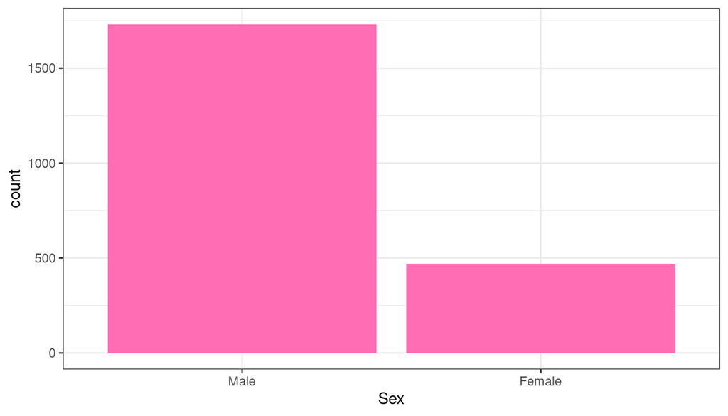

```r
ggplot(titanic, aes(Sex)) + geom_bar(fill = 'hotpink1')
```

Additionally, we see in both cases that all of our observations are included in the count, as both of the table totals sum up to 2201. We can verify this with the helper function `addmargins` which will include a “Sum” column adding up the table

```r
## Assign table to tab variable
tab <- table(titanic$Survived)

## Adds the Sum value
addmargins(tab)
```

```
##
##   No  Yes  Sum
## 1490  711 2201
```

Notice how in this case we first assigned the result of `table()` to a variable and then passed that variable to `addmargins()`. This is an excellent example of a process that is facilitated with the pipe operator, `%>%` (Ctrl+Shift+M):

```r
## This is equivalent to what we saw above
table(titanic$Survived) %>% addmargins()
```

```
##
##   No  Yes  Sum
## 1490  711 2201
```

We may also be interested in identifying the *proportion* of individuals who survived or died on the Titanic. Similar to the `addmargins()` function, we can pass the results of `table()` to the function `proportions()`

```r
table(titanic$Survived) %>% proportions()
```

```
##
##      No     Yes
## 0.67697 0.32303
```

Here we see that 68% of the passengers aboard the Titanic died while 32% survived. This is the same information that we would have found had we computed the values by hand:

$$\text{% Dead} = \frac{\# \text{Dead}}{\text{Total Passengers}} =
\frac{1490}{2201} = 0.677$$
Finally, let’s introduce the `sort()` function, which takes either a one-way table or a vector and sorts the values from smallest to largest (or in alphabetical order if they are character strings)

```r
## Unsorted table
table(titanic$Class)
```

```
##
##  1st  2nd  3rd Crew
##  325  285  706  885
```

```r
## Table sorted smallest to largest
table(titanic$Class) %>% sort()
```

```
##
##  2nd  1st  3rd Crew
##  285  325  706  885
```

```r
## Table sorted largest to smallest
table(titanic$Class) %>% sort(decreasing = TRUE)
```

```
##
## Crew  3rd  1st  2nd
##  885  706  325  285
```

There are a few things to note about the `sort()` function:

1. Like `addmargins()` and `proportions()`, we can pass an argument to `sort()` using the pipe operator `%>%`
2. By default, `sort()` reorders observations from smallest to largest. We can change this behavior by adding `decreasing = TRUE` as an argument to `sort()` as we did above
3. When we have a *named vector*, i.e., a set of values with names, such as the case with the table above, `sort()` will sort the vector according to its values, not its names.

Let’s practice using some of these functions on the Titanic dataset.

**Question 1:**

- Create a *frequency table* using the `titanic` data set to find how many children and adults were on board the Titanic.
- Determine what percentage of the passengers on-board the Titanic were adults.
- Determine what percentage of the passengers on-board the Titanic survived.
- Below is an example of using the pipe operator twice in a row to both add proportions and margins to a table. Does it matter which order we include them in? Why? Which of these is correct?

```r
table(titanic$Age) %>% addmargins() %>% proportions()
```

```
##
##    Child    Adult      Sum
## 0.024761 0.475239 0.500000
```

```r
table(titanic$Age) %>% proportions() %>% addmargins()
```

```
##
##    Child    Adult      Sum
## 0.049523 0.950477 1.000000
```

### Two-way Tables

The two-way table, as the name suggests, is a table of two categorical variables. In R, this can be done by passing each of the two vectors in as arguments, with the first vector becoming the rows and the second becoming the column:

```r
## Sex as row
table(titanic$Sex, titanic$Survived)
```

```
##
##            No  Yes
##   Male   1364  367
##   Female  126  344
```

```r
## Sex as column
table(titanic$Survived, titanic$Sex)
```

```
##
##       Male Female
##   No  1364    126
##   Yes  367    344
```

A simplified syntax for performing this operation can be done using `with()`, though this is completely optional. I will use it for clarity and brevity, though all of the examples shown will work with the syntax above. One minor benefit to using `with()` is that the table now includes the name of the variable along with it’s values (notice that the labels “Sex” and “Survived” are missing in the tables above):

```r
## Simplified syntax using with()
with(titanic, table(Sex, Survived))
```

```
##         Survived
## Sex        No  Yes
##   Male   1364  367
##   Female  126  344
```

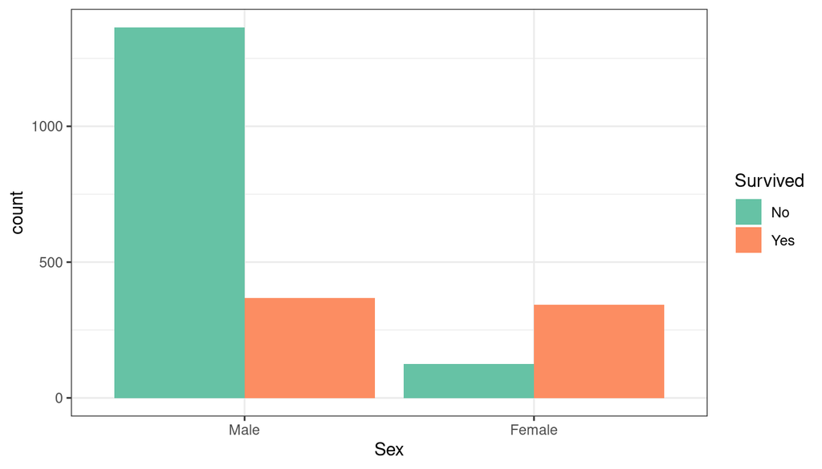

```r
ggplot(titanic, aes(Sex, fill = Survived)) +
  geom_bar(position = "dodge") +
  scale_fill_brewer(palette = "Set2")
```

We can recover the information from the one-way tables by using `addmargins()` to give us row and column totals

```r
## Add row and column margins to  plots
with(titanic, table(Sex, Survived)) %>% addmargins()
```

```
##         Survived
## Sex        No  Yes  Sum
##   Male   1364  367 1731
##   Female  126  344  470
##   Sum    1490  711 2201
```

We should see that the Sum row and columns are exactly the one-way tables we created in the last section. In both cases, we see they sum to 2201 in the bottom right corner.

Just as before, we can pass a two-way table to the `proportions()` function to return a table of proportions:

```r
with(titanic, table(Sex, Survived)) %>% proportions()
```

```
##         Survived
## Sex            No      Yes
##   Male   0.619718 0.166742
##   Female 0.057247 0.156293
```

Note that these are *absolute proportions*, calculated by dividing each of the entries in the two-way table by its total of 2201. This table of proportions tells us, for example, that *of all of the passengers* who were on the Titanic, 62% of them were males who died.

```r
# Compute row proportions
with(titanic, table(Sex, Survived)) %>% proportions(margin = 1)
```

```
##         Survived
## Sex           No     Yes
##   Male   0.78798 0.21202
##   Female 0.26809 0.73191
```

From this, we see that *given that an individual was male*, 21% survived while 79% perished. Similarly, *given that an individual was female*, we see that 27% were cast to a watery grave while 73% went to normal graves at some other point in their lives. In this example, we are *conditioning* on sex, our explanatory variable, with survival status serving as our response.

The variable we condition on should also serve as the x-axis in any conditional plots we make

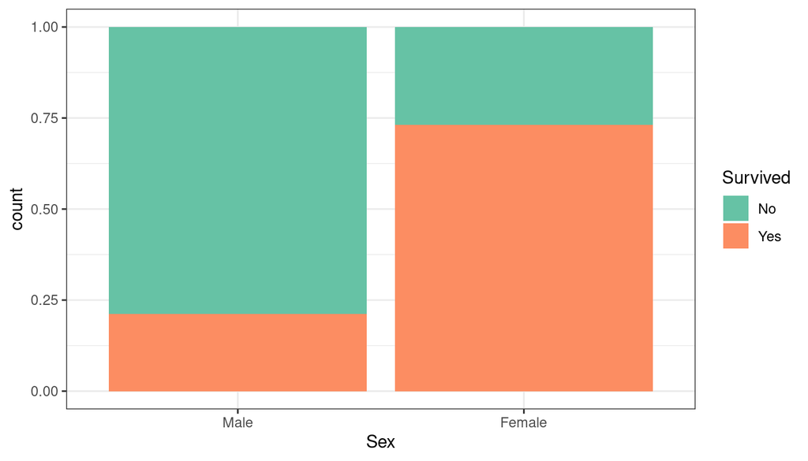

```r
ggplot(titanic, aes(Sex, fill = Survived)) +
  geom_bar(position = "fill") +
  scale_fill_brewer(palette = "Set2")
```

Finding column proportions works the same way, passing `margin = 2` into our function instead

```r
# Compute column proportions
with(titanic, table(Sex, Survived)) %>% proportions(margin = 2)
```

```
##         Survived
## Sex            No      Yes
##   Male   0.915436 0.516174
##   Female 0.084564 0.483826
```

Doing so replaces which variable we include as the x-axis on our plot

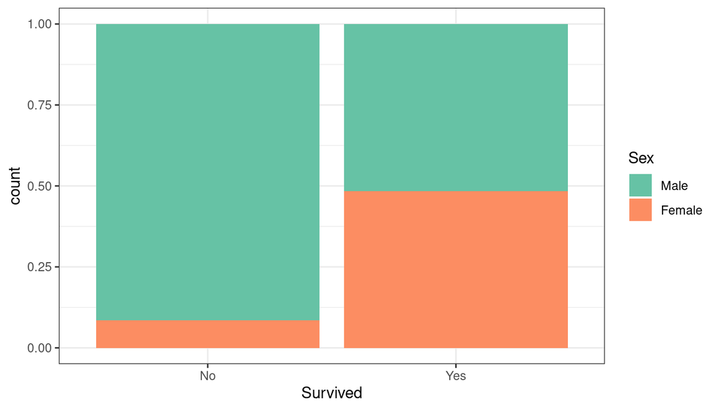

```r
ggplot(titanic, aes(Survived, fill = Sex)) +
  geom_bar(position = "fill") +
  scale_fill_brewer(palette = "Set2")
```

We will wrap up this section by showing the use of `addmargins()` for two-way tables. Just like `proportions()`, `addmargins()` also takes an argument telling it which margin to take the sum, though it is unfortunately backwards from what we think based on the `proportions()` function:

```r
## Row and column margins
with(titanic, table(Sex, Age)) %>% addmargins()
```

```
##         Age
## Sex      Child Adult  Sum
##   Male      64  1667 1731
##   Female    45   425  470
##   Sum      109  2092 2201
```

```r
## Adds a row for sums (across the columns)
with(titanic, table(Sex, Age)) %>% addmargins(margin = 1)
```

```
##         Age
## Sex      Child Adult
##   Male      64  1667
##   Female    45   425
##   Sum      109  2092
```

```r
## Adds a column for sums (across the rows)
with(titanic, table(Sex, Age)) %>% addmargins(margin = 2)
```

```
##         Age
## Sex      Child Adult  Sum
##   Male      64  1667 1731
##   Female    45   425  470
```

Let’s conclude this section with a little bit of practice.

**Question 2:**

- How many children were included in second class?
- What percentage of the crew survived? How about children?
- What proportion of individuals who survived were members of the crew? Construct the plot associated with the table you create.

## Three-way tables

A natural extension of the two-way table is the three-way table (and so on). These differ from the two-way and one-way tables in that switching the order of the variables is no longer as simple as changing out the rows and columns. We won’t be asked to do much with three-way tables, but it is worth considering what information can be gained from them. Consider for example the two table below:

```r
## Table 1
with(titanic, table(Class, Sex, Survived))
```

```
## , , Survived = No
##
##       Sex
## Class  Male Female
##   1st   118      4
##   2nd   154     13
##   3rd   422    106
##   Crew  670      3
##
## , , Survived = Yes
##
##       Sex
## Class  Male Female
##   1st    62    141
##   2nd    25     93
##   3rd    88     90
##   Crew  192     20
```

```r
## Table 2
with(titanic, table(Sex, Class, Survived))
```

```
## , , Survived = No
##
##         Class
## Sex      1st 2nd 3rd Crew
##   Male   118 154 422  670
##   Female   4  13 106    3
##
## , , Survived = Yes
##
##         Class
## Sex      1st 2nd 3rd Crew
##   Male    62  25  88  192
##   Female 141  93  90   20
```

Complimentary to the three-way table, we introduce here the `ggplot2` function `facet_grid()`; it works just as `facet_wrap()`, except it takes *two* categorical variables and creates a grid of facets

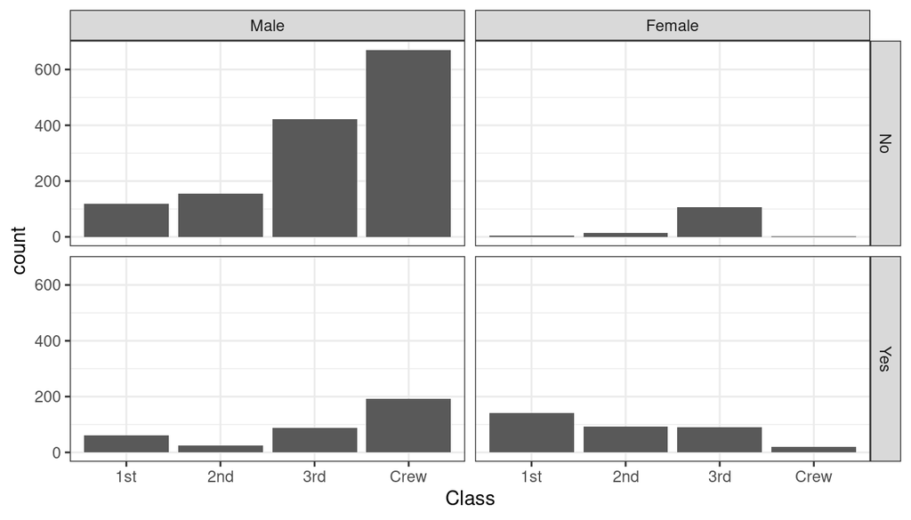

```r
ggplot(titanic, aes(Class)) +
  geom_bar() +
  facet_grid(Survived ~ Sex)
```

There are no questions for this section, but you should be aware of the `facet_grid()` function and how it works.

## Odds Ratios and Contingency Tables

In class, we introduced the *contingency table*, a special two-way table made up of binary variables, common in fields of epidemiology and biostatistics:

|  | Event | Non-Event |
| --- | --- | --- |
| Exposure | A | B |
| No Exposure | C | D |

Given a table such as this, we are often interested in asking if the response variable (columns) are associated with the explanatory variable (rows). While there are a multitude of methods for doing so, we have limited our discussion for now to the topic of odds and odds ratios.

While there are several packages available in R to facilitate this, most of them include machinery beyond what we currently need. As such, we will briefly detail how to do it manually here.

First, we should understand that data in R (including matrices and tables) are stored in *column order* meaning that if we were to index all of the elements from 1 to the last, we would begin with the first element being in the top left and then interatively proceed down the column. For example, consider this matrix with multiples of ten as its entries:

```r
mm <- matrix(10*1:4, nrow = 2)
mm
```

```
##      [,1] [,2]
## [1,]   10   30
## [2,]   20   40
```

The “first” element of this matrix is 10 since it is in the top left, and we can access it similar to how we selected elements of a vector the previous lab

```r
## The first element is 10
mm[1]
```

```
## [1] 10
```

Moving vertically down the column, we see that our second should be 20. This ends the first column so we start again at the next, giving us our third as 30, and finally the fourth as 40.

```r
mm[2]
```

```
## [1] 20
```

```r
mm[3]
```

```
## [1] 30
```

```r
mm[4]
```

```
## [1] 40
```

Now consider a table from the titanic data looking survival for men and women

```r
tab <- with(titanic, table(Sex, Survived))
tab
```

```
##         Survived
## Sex        No  Yes
##   Male   1364  367
##   Female  126  344
```

The indexing works the same. If I wanted to find the total number of men who survived, I would start counting down from the top left and see that it is the third position. As such, I would extract it with the index 3

```r
tab[3]
```

```
## [1] 367
```

To find the odds of a male dying, we then divide the two numbers in the first row; from above, we know these are positions 1 and 3

```r
## odds of man dying
tab[1] / tab[3]
```

```
## [1] 3.7166
```

This tells us that 3.7 men died for each one that lived. For women, the computation is similar, selecting the second and fourth positions:

```r
## odds of woman dying
tab[2] / tab[4]
```

```
## [1] 0.36628
```

Here we see that 0.36 women died for each one that lived. In order to see how the odds differ between groups, we then evaluate the *odds ratio*, the ratio between these two groups

```r
man_odds <- tab[1] / tab[3]
woman_odds <- tab[2] / tab[4]

man_odds / woman_odds
```

```
## [1] 10.147
```

We find that the odds of a man dying aboard the Titanic were 10 times that of a woman dying, suggesting that there may be some association between these two variables. To facilitate our work for this lab, I have included a small function here that, given a contingency table, will report back the odds ratio for you.

```r
## Function called or()
or <- function(x) {
  (x[1] * x[4]) / (x[2] * x[3])
}

## Create a 2x2 table
tab <- with(titanic, table(Sex, Survived))

## Pass table as argument to or()
or(tab)
```

```
## [1] 10.147
```

As a **critical note** about odds and tables – when reporting odds, we need to be conscientious of what is our “success” or “event” and what is considered “failure” or “no event”. Our formula assumes the first column of our table to be *event*. In the case of Titanic data, this refers to death, so when we speak of odds, we are talking about the *odds of dying*. If we are interested in discussing the *odds of living*, we need to change the order of the columns. We do that like this:

```r
## This is our original table
tab
```

```
##         Survived
## Sex        No  Yes
##   Male   1364  367
##   Female  126  344
```

```r
## Here, we switch columns, when we include numbers after
# a comma, we are referring to column numbers. In this case, we are
# saying that we want column 2 first, and  then column 1
tab[, c(2, 1)]
```

```
##         Survived
## Sex       Yes   No
##   Male    367 1364
##   Female  344  126
```

```r
## I can save these results to my table to override
tab <- tab[, c(2, 1)]
tab
```

```
##         Survived
## Sex       Yes   No
##   Male    367 1364
##   Female  344  126
```

**Question 3** Create a contingency table showing the age of the passenger (Child or Adult) and their survival. How do the odds of dying as an adult compare with the odds of dying as a child? Would you say there is an association between age and survival? Find the odds ratio in support of your conclusion.

## Lab

Start by copying the code block below to modify the data as it is built-in in R to something we are used to working with. Then, answer the following questions.

```r
## Create UC Berkeley data from built-in R dataset
ucb <- as.data.frame(UCBAdmissions)
ucb <- ucb[rep(1:nrow(ucb), times = ucb$Freq), ]
ucb$Freq <- NULL
```

1. Create the appropriate table to illustrate the frequency of male and female applicants and whether or not their application was accepted.
2. Using your table from (a), compute the odds ratio of a male applicant being accepted over a female one. Does it appear that there is any evidence of sex bias?
3. Which departments appear to have the greatest total number of male applicants? Which departments had the greatest total number of female applicants?
4. Which two departments appear to have the highest proportion of applications accepted? Of applications rejected?
5. Based on what we have seen in the first parts of this question, what do you suspect is happening? Create two plots to help tell this story: the first plot should be suggestive of gender bias at UCB, while the second should demonstrate how the question is resolved, either concluding with evidence of gender bias or providing evidence to refute it. Consider which *attributes* of the problem you find most compelling in support of your argument (number of students, proportions, etc). Finally, in 3-4 sentences, summarize your findings and justify the two plots selected to illustrate the problem.